# Alexandra Cathcart

mod7_SYS6018_Alexandra_Cathcart

# Module 8 - Chapter 8 - 8.4 Exercises

## Problem # 7

### **In the lab, we applied random forests to the Boston data using mtry=6 and using ntree=25 and ntree=500. Create a plot displaying the test error resulting from random forests on this data set for a more comprehensive range of values for mtry and ntree. You can model your plot after Figure 8.10. Describe the results obtained.**

```r
library(tree)
library(randomForest)
library(MASS)
library(ISLR)
library(gbm)
library(class)
```

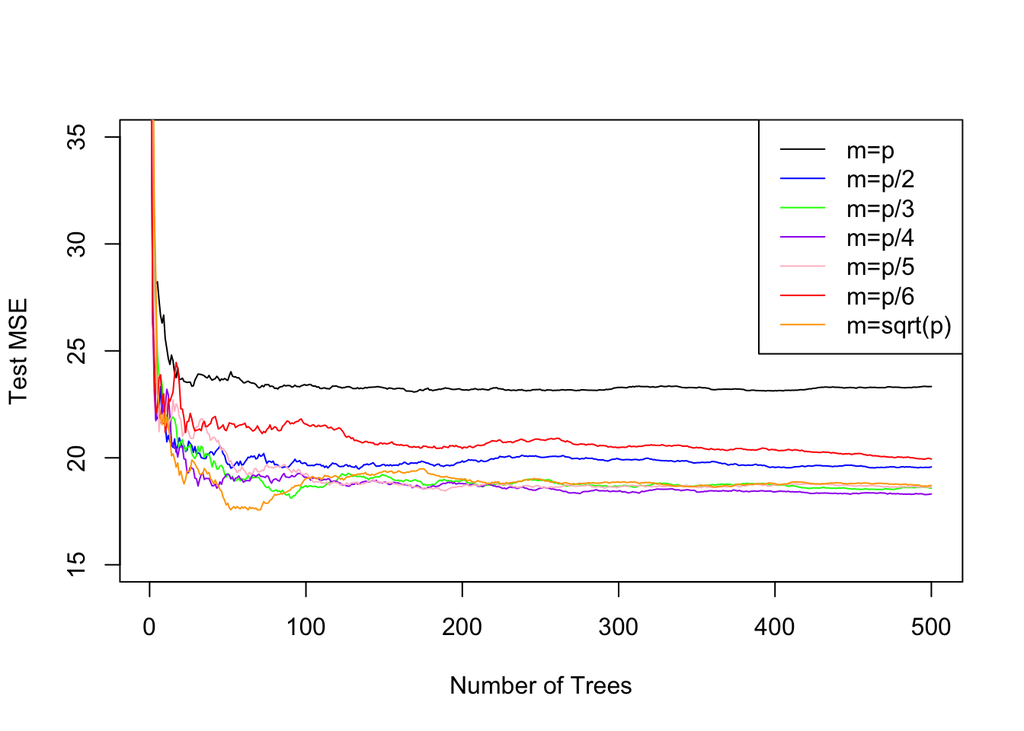

```r
#Create a plot displaying the test error resulting from random forests on this data set for a more comprehensive range of values for mtry and ntree.

#Split test/train
set.seed(1)
subset<-sample(1:nrow(Boston),nrow(Boston)/2)
Boston.train<-Boston[subset,-14]
Boston.test<-Boston[-subset,-14]
y.train<-Boston[subset,14]
y.test<-Boston[-subset,14]
#Assign 7 models, three matching those in figure 8.10, four that build onto that set
rf.mod1<-randomForest(Boston.train,y.train,Boston.test,y.test,ntree=500,mtry=ncol(Boston.train))
rf.mod2<-randomForest(Boston.train,y.train,Boston.test,y.test,ntree=500,mtry=(ncol(Boston.train))/2)
rf.mod3<-randomForest(Boston.train,y.train,Boston.test,y.test,ntree=500,mtry=(ncol(Boston.train))/3)
rf.mod4<-randomForest(Boston.train,y.train,Boston.test,y.test,ntree=500,mtry=(ncol(Boston.train))/4)
rf.mod5<-randomForest(Boston.train,y.train,Boston.test,y.test,ntree=500,mtry=(ncol(Boston.train))/5)
rf.mod6<-randomForest(Boston.train,y.train,Boston.test,y.test,ntree=500,mtry=(ncol(Boston.train))/6)
rf.mod7<-randomForest(Boston.train,y.train,Boston.test,y.test,ntree=500,mtry=(ncol(Boston.train))^(0.5))
#Assign 5 models
plot(1:500,rf.mod1$test$mse,col="black",type="l",xlab = "Number of Trees",ylab = "Test MSE",ylim = c(15,35))
lines(1:500,rf.mod2$test$mse, col="blue",type="l")
lines(1:500,rf.mod3$test$mse, col="green",type="l")
lines(1:500,rf.mod4$test$mse, col="purple",type="l")
lines(1:500,rf.mod5$test$mse, col="pink",type="l")
lines(1:500,rf.mod6$test$mse, col="red",type="l")
lines(1:500,rf.mod7$test$mse, col="orange",type="l")
legend("topright",c("m=p","m=p/2","m=p/3","m=p/4","m=p/5","m=p/6","m=sqrt(p)"),col=c("black","blue","green","purple","pink","red","orange"),cex=1,lty=1)
```

- Describe the results obtained:
  - As ntree increases, the MSE decreases and then levels off. Similarly, as mtry gets smaller, the overall MSE measurement gets lower, until models 5 & 6 where we stop seeing improvement. The lowest MSE of all models is achieved with m=sqrt(p) and ~50-75 trees.

## Problem # 8

### **In the lab, a classification tree was applied to the Carseats data set after converting Sales into a qualitative response variable. Now we will seek to predict Sales using regression trees and related approaches, treating the response as a quantitative variable.**

**(a) Split the data set into a training set and a test set.**

```r
#Split the data set into a training set and a test set
set.seed(1)
subset<-sample(nrow(Carseats),nrow(Carseats)*0.7)
carseats.train<-Carseats[subset,]
carseats.test<-Carseats[-subset,]
```

**(b) Fit a regression tree to the training set. Plot the tree, and interpret the results. What test MSE do you obtain?**

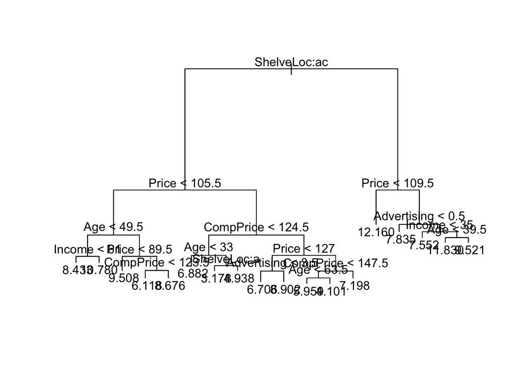

```r
#Fit a regression tree to the training set
carseats.tree <- tree(Sales ~ .,carseats.train)
#Plot the tree
plot(carseats.tree)
text(carseats.tree)
```

```r
#Obtain MSE
carseats.tree.pred<-predict(carseats.tree,carseats.test)
(carseats.tree.mse<-mean((carseats.test$Sales-carseats.tree.pred)^2))
```

```
## [1] 4.208383
```

- What test MSE do you obtain?:
  - Test MSE: 4.208383.

**(c) Use cross-validation in order to determine the optimal level of tree complexity. Does pruning the tree improve the test MSE?**

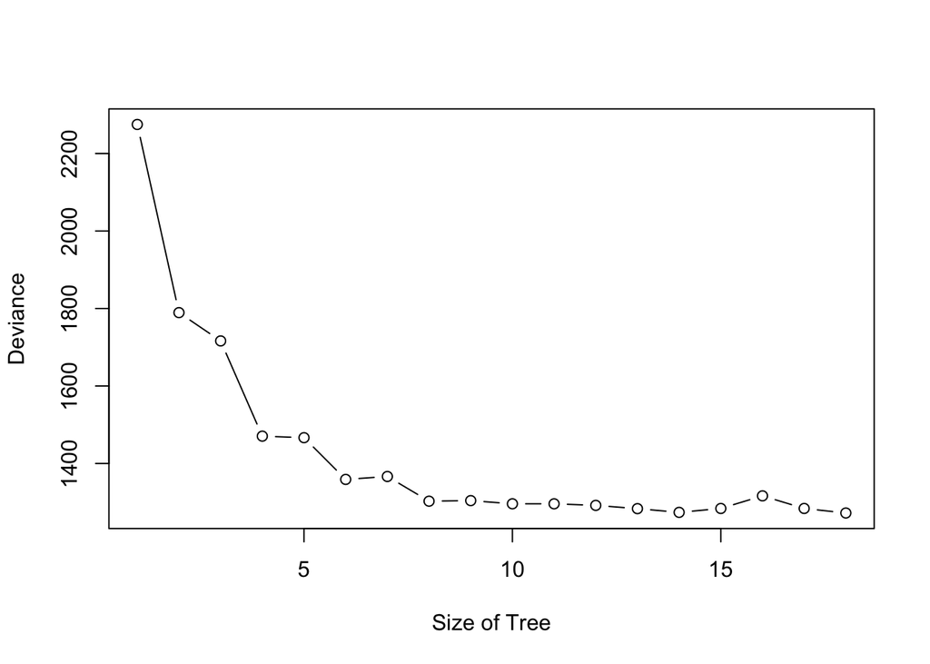

```r
#Use cross-validation  to determine the optimal level of tree complexity.
carseats.cv<-cv.tree(carseats.tree, FUN = prune.tree)
plot(carseats.cv$size,carseats.cv$dev,xlab = "Size of Tree",ylab = "Deviance",type = "b")
```

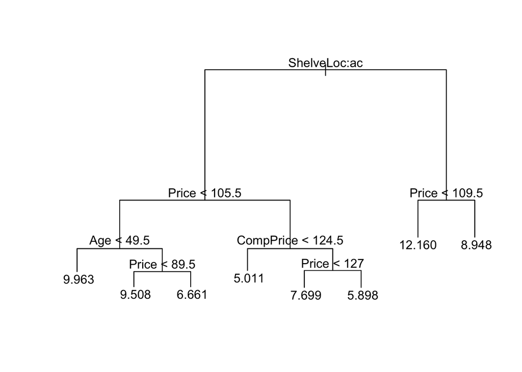

```r
#Prune the tree according to the optimal tree complexity
carseats.tree.prune<-prune.tree(carseats.tree,best=8)
plot(carseats.tree.prune)
text(carseats.tree.prune)
```

```r
#Calculate new MSE
carseats.pruned.pred<-predict(carseats.tree.prune,carseats.test)
(carseats.pruned.mse<-mean((carseats.pruned.pred-carseats.test$Sales)^2))
```

```
## [1] 4.579256
```

- Does pruning the tree improve the test MSE?:
  - No, pruning the tree does not improve the test MSE. The test MSE obtained from the pruned tree is 4.579256, compared to the full tree test MSE of 4.208383.

**(d) Use the bagging approach in order to analyze this data. What test MSE do you obtain? Use the importance() function to determine which variables are most important.**

```r
#Use the bagging approach in order to analyze this data.
carseats.bag <- randomForest(Sales ~ .,carseats.train,mtry = 10,ntree = 500,importance = TRUE)
carseats.bag.pred <- predict(carseats.bag,carseats.test)
(carseats.bag.mse <- mean((carseats.bag.pred - carseats.test$Sales)^2))
```

```
## [1] 2.540992
```

```r
#Use the importance() function to determine which variables are most important.
importance(carseats.bag)
```

```
##                %IncMSE IncNodePurity
## CompPrice   33.7743862     228.91321
## Income       6.0942550     118.68202
## Advertising 18.6617139     153.90381
## Population  -0.5498118      65.13690
## Price       66.5408316     687.49056
## ShelveLoc   67.2755302     634.93813
## Age         20.2323914     227.02999
## Education    1.7403062      63.19110
## Urban       -0.0555473      11.43354
## US          -0.3669702      11.04510
```

**(e) Use random forests to analyze this data. What test MSE do you obtain? Use the importance() function to determine which variables are most important. Describe the effect of m, the number of variables considered at each split, on the error rate obtained.**

```r
p <- ncol(Carseats) - 1
#Use random forests to analyze this data. mtry = sqrt(p)
carseats.randf1 <- randomForest(Sales ~ .,carseats.train,mtry = sqrt(p),ntree = 500,importance = TRUE)
carseats.randf.pred1 <- predict(carseats.randf1,carseats.test)
(carseats.randf.mse1 <- mean((carseats.test$Sales - carseats.randf.pred1)^2))
```

```
## [1] 2.862987
```

```r
#Use the importance() function to determine which variables are most important.
importance(carseats.randf1)
```

```
##                %IncMSE IncNodePurity
## CompPrice   17.6208035     210.20144
## Income       4.2057215     161.10896
## Advertising 12.9084644     162.02173
## Population  -2.5611283     134.21794
## Price       45.4429707     548.63871
## ShelveLoc   44.4055881     509.39047
## Age         18.6482348     270.10708
## Education    1.9219385      97.33615
## Urban       -0.7258283      20.87099
## US           5.6233465      29.07053
```

```r
#-------

#Use random forests to analyze this data. mtry = p/3
carseats.randf2 <- randomForest(Sales ~ .,carseats.train,mtry = p/3,ntree = 500,importance = TRUE)
carseats.randf.pred2 <- predict(carseats.randf2,carseats.test)
(carseats.randf.mse2 <- mean((carseats.test$Sales - carseats.randf.pred2)^2))
```

```
## [1] 2.902763
```

```r
#Use the importance() function to determine which variables are most important.
importance(carseats.randf2)
```

```
##               %IncMSE IncNodePurity
## CompPrice   18.559209     206.72991
## Income       2.598501     165.63708
## Advertising 14.449997     156.18610
## Population  -1.522910     134.25624
## Price       47.295554     559.41792
## ShelveLoc   47.509535     495.49350
## Age         14.213430     267.83374
## Education    1.185499      93.77276
## Urban       -2.222493      19.75409
## US           3.418544      30.12019
```

```r
#-------

#Use random forests to analyze this data. mtry = 5
carseats.randf3 <- randomForest(Sales ~ .,carseats.train,mtry = 5,ntree = 500,importance = TRUE)
carseats.randf.pred3 <- predict(carseats.randf3,carseats.test)
(carseats.randf.mse3 <- mean((carseats.test$Sales - carseats.randf.pred3)^2))
```

```
## [1] 2.590335
```

```r
#Use the importance() function to determine which variables are most important.
importance(carseats.randf3)
```

```
##                %IncMSE IncNodePurity
## CompPrice   22.8412398     216.49391
## Income       5.3741856     138.63321
## Advertising 18.9013887     159.50060
## Population  -0.2746493      94.68249
## Price       56.0450900     621.85950
## ShelveLoc   57.8550737     566.43722
## Age         19.5819648     262.05075
## Education    1.7450895      78.38997
## Urban       -0.7361814      14.81945
## US           3.3954738      22.15163
```

```r
#-------

#Use random forests to analyze this data. mtry = p
carseats.randf4 <- randomForest(Sales ~ .,carseats.train,mtry = p,ntree = 500,importance = TRUE)
carseats.randf.pred4 <- predict(carseats.randf4,carseats.test)
(carseats.randf.mse4 <- mean((carseats.test$Sales - carseats.randf.pred4)^2))
```

```
## [1] 2.589244
```

```r
#Use the importance() function to determine which variables are most important.
importance(carseats.randf4)
```

```
##                %IncMSE IncNodePurity
## CompPrice   32.3128785     233.14532
## Income       7.5897760     114.19321
## Advertising 18.3113005     155.78102
## Population  -0.2289711      66.26936
## Price       72.1005785     680.07001
## ShelveLoc   71.3744107     631.19967
## Age         20.2701569     230.06383
## Education    3.1062743      62.40107
## Urban       -0.9756599      10.41581
## US           2.4194931      11.52957
```